# 10_PCA_biplot_cell_lines

Andrea Polazzi

2026-03-23

# Setup

```r
library(tidyverse)
```

```r
library(readxl)
source('../scripts/useful_plots.R')
data <- read_xlsx('../data/raw/tab1.xlsx')
```

# Motifs subset

We keep only a subset of variables, corresponding to the ones we have available for primary tumors.

```r
pca_data <- data %>%
  select(`ALT assay strength`, TelFusDetector_rate, TelFuse_newtelomere, TelSeq, TERT_exp, ATAGGG, CTAGGG, GTAGGG, TAAGGG, TCAGGG, TGAGGG, TTCGGG, TTTGGG) %>%
  drop_na() %>%
  rename(alt_status=`ALT assay strength`, tf_rate = TelFusDetector_rate, tel_insertion_rate = TelFuse_newtelomere, tel_content = TelSeq) %>%
  mutate(alt_status = as.factor(alt_status))
```

We retain 83 observations (63 experimentally confirmed as non-ALT, 20 as ALT) but **we don’t have the TTGGGG column**.

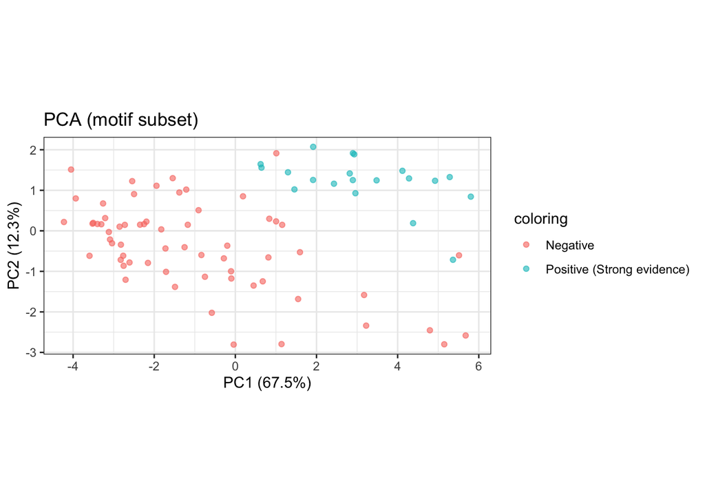

```r
pcaplt <- pca_plot(pca_data, title = 'PCA (motif subset)')
pcaplt$plot
```

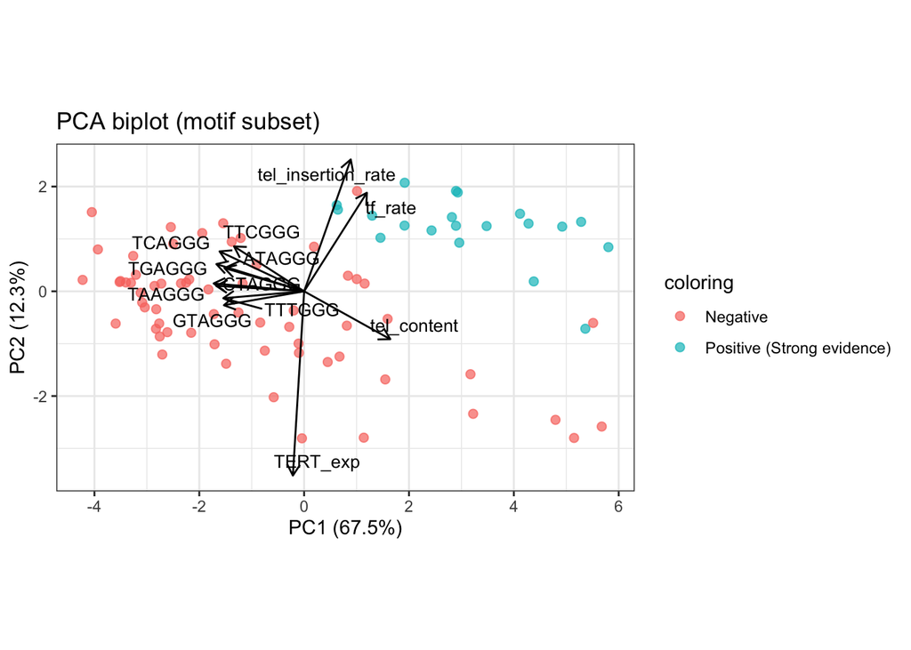

```r
biplot <- pca_biplot(pca_data, title = 'PCA biplot (motif subset)', scale_arrows = 5)
biplot$plot
```

# Repeat using TVR column instead of individual motifs

```r
pca_data <- data %>%
  select(`ALT assay strength`, TelFusDetector_rate, TelFuse_newtelomere, TelSeq, TVR, TERT_exp) %>%
  drop_na() %>%
  rename(alt_status=`ALT assay strength`, tf_rate = TelFusDetector_rate, tel_insertion_rate = TelFuse_newtelomere, tel_content = TelSeq) %>%
  mutate(alt_status = as.factor(alt_status))
```

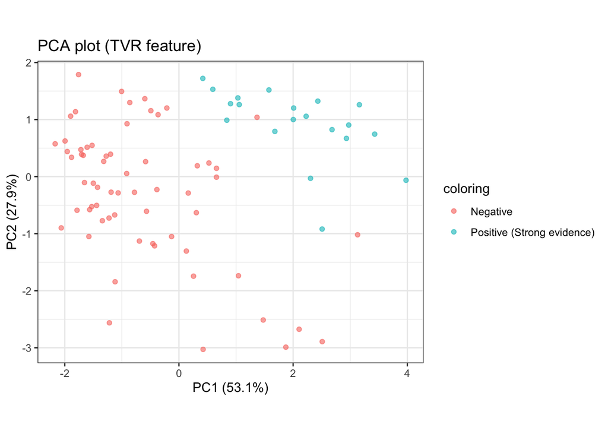

```r
pcaplt <- pca_plot(pca_data, title = 'PCA plot (TVR feature)')
pcaplt$plot
```

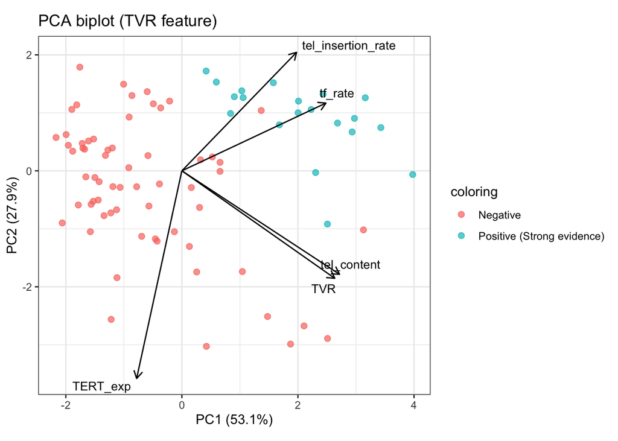

```r
biplot <- pca_biplot(pca_data, title = 'PCA biplot (TVR feature)', scale_arrows = 5)
biplot$plot
```

This is an **almost exact replica of the paper’s Fig 1B**.

# Decompose TVR feature in individual motifs

```r
pca_data <- data %>%
  select(`ALT assay strength`, TelFusDetector_rate, TelFuse_newtelomere, TelSeq, 6:54, TERT_exp) %>%
  drop_na() %>%
  rename(alt_status=`ALT assay strength`, tf_rate = TelFusDetector_rate, tel_insertion_rate = TelFuse_newtelomere, tel_content = TelSeq) %>%
  mutate(alt_status = as.factor(alt_status))
```

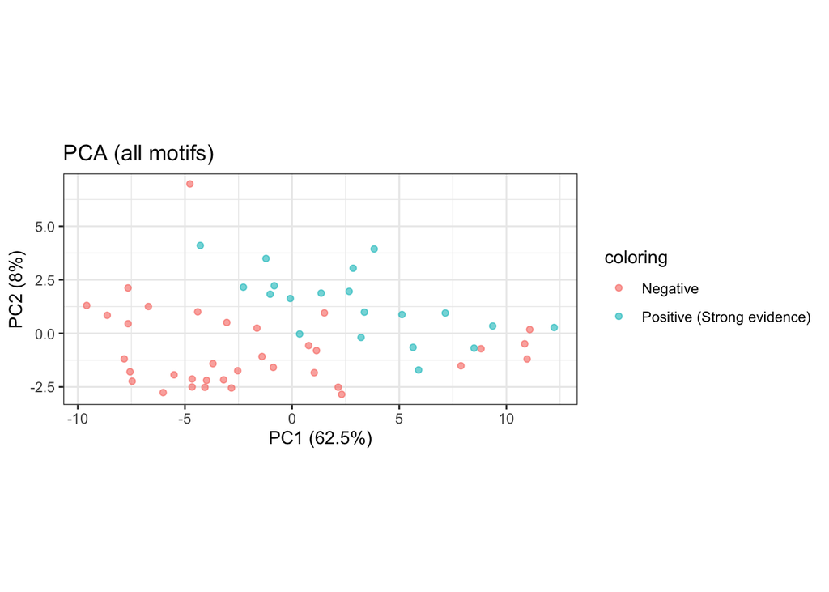

```r
pcaplt <- pca_plot(pca_data, title = 'PCA (all motifs)')
pcaplt$plot
```

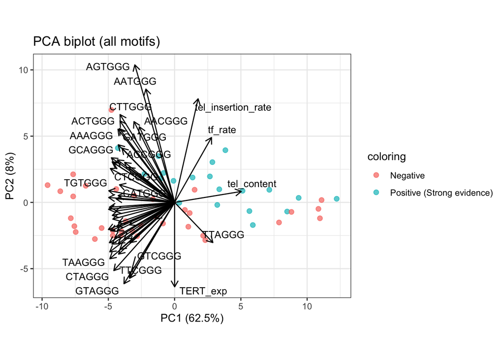

```r
biplot <- pca_biplot(pca_data, title = 'PCA biplot (all motifs)', scale_arrows = 30)
biplot$plot
```

# Interpretation and discussion

In the **PCAWG primary tumor dataset**, the biplot revealed a clear separation of ALT-high tumors along PC1 (53.1%), driven primarily by tel_insertion_rate, tf_rate, and tel_content. Notably, specific TVR motifs, in particular TTCGGG and TGAGGG, loaded in the direction of ALT-high samples, while TTTGGG loaded in the opposite direction. These results are **consistent with published literature** and **confirmed by supervised classification results**.

Two additional exploratory biplots were generated using raw individual motif frequencies from the cell line dataset. In both cases, the motif vectors pointed toward ALT-negative samples, **opposite to what was observed in the PCAWG dataset**. **In PCAWG, motif values are per-sample normalized z-scores** (singleton distances), whereas **in the cell line dataset they are raw frequencies** subject to sequencing depth variation and batch effects. Without applying the batch-correction pipeline used by Bennett et al. (log-transformation followed by regression on depth-derived principal components) individual motif frequencies are not directly interpretable in the context of ALT biology, and direct comparison with the PCAWG results is not valid.

# Restrict to primary tumors only

Importantly, I noticed that **the training set they used**, and on which I replicated their PCA, **contained both primary AND metastatic tumors**. We could see if, retaining only primary tumors, the same feature contributions to PCA emerge.

```r
pca_data_primary <- data %>%
  filter(PrimaryOrMetastasis == 'Primary') %>%
  select(`ALT assay strength`, TelFusDetector_rate, TelFuse_newtelomere, TelSeq, TERT_exp, ATAGGG, CTAGGG, GTAGGG, TAAGGG, TCAGGG, TGAGGG, TTCGGG, TTTGGG) %>%
  drop_na() %>%
  rename(alt_status=`ALT assay strength`, tf_rate = TelFusDetector_rate, tel_insertion_rate = TelFuse_newtelomere, tel_content = TelSeq) %>%
  mutate(alt_status = as.factor(alt_status))
```

We have **only 50 observations** (38 non-ALT, 12 ALT).

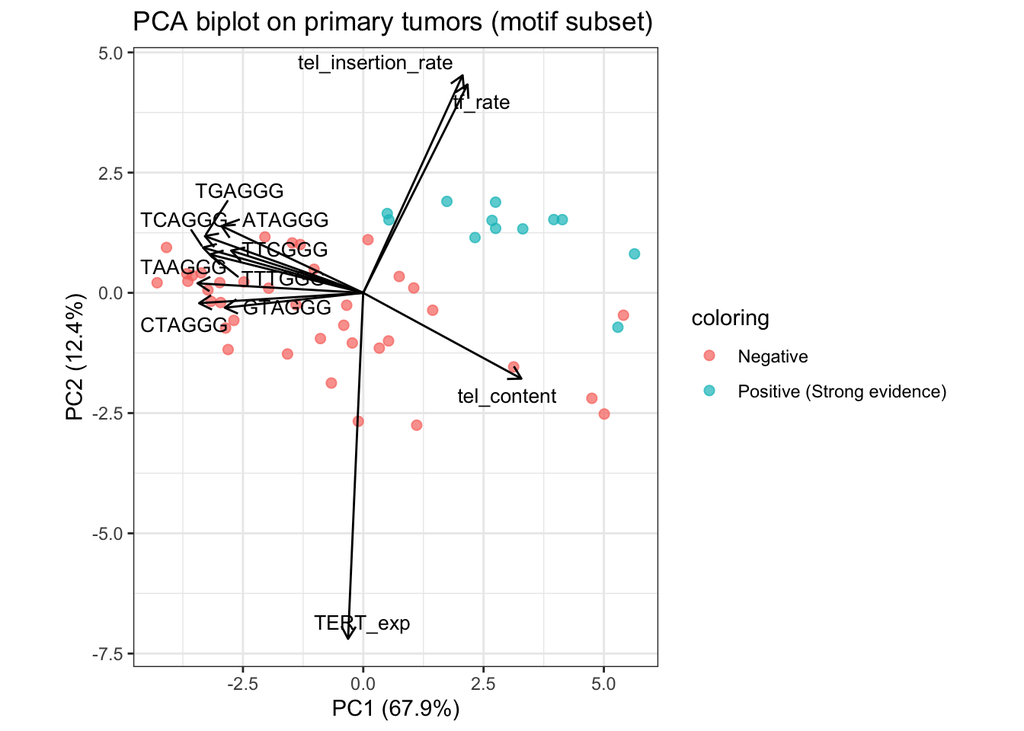

```r
biplot <- pca_biplot(pca_data_primary, title = 'PCA biplot on primary tumors (motif subset)')
biplot$plot
```

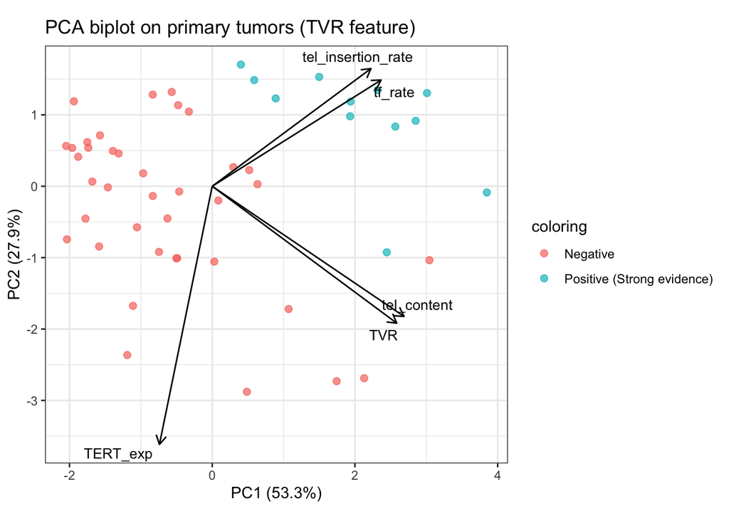

```r
pca_data_primary <- data %>%
  filter(PrimaryOrMetastasis=='Primary') %>%
  select(`ALT assay strength`, TelFusDetector_rate, TelFuse_newtelomere, TelSeq, TVR, TERT_exp) %>%
  drop_na() %>%
  rename(alt_status=`ALT assay strength`, tf_rate = TelFusDetector_rate, tel_insertion_rate = TelFuse_newtelomere, tel_content = TelSeq) %>%
  mutate(alt_status = as.factor(alt_status))

biplot <- pca_biplot(pca_data_primary, title = 'PCA biplot on primary tumors (TVR feature)', scale_arrows = 5)
biplot$plot
```

```r
pca_data_primary <- data %>%
  filter(PrimaryOrMetastasis=='Primary') %>%
  select(`ALT assay strength`, TelFusDetector_rate, TelFuse_newtelomere, TelSeq, 6:54, TERT_exp) %>%
  drop_na() %>%
  rename(alt_status=`ALT assay strength`, tf_rate = TelFusDetector_rate, tel_insertion_rate = TelFuse_newtelomere, tel_content = TelSeq) %>%
  mutate(alt_status = as.factor(alt_status))
```

We have **even fewer observations** (20 non-ALT, 12 ALT), since many rows have NA values in individual motifs columns.

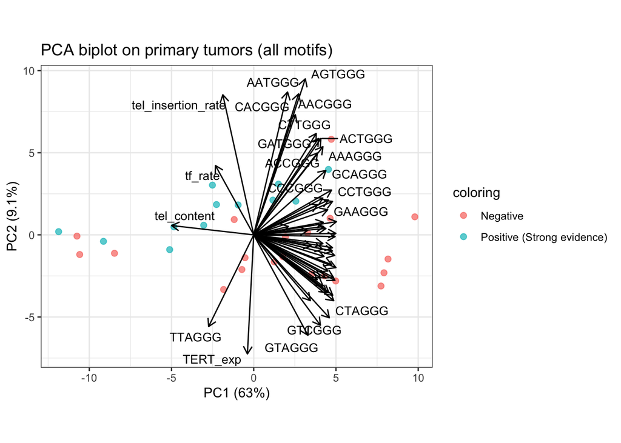

```r
biplot <- pca_biplot(pca_data_primary, title = 'PCA biplot on primary tumors (all motifs)', scale_arrows = 30)
biplot$plot
```

By looking at the resulting PCA biplots, we can see how the **contributions of features in the PCA is very much the same as before**, even when restricting the analysis only for primary tumor cell lines.

# Using a larger dataset

We will now re-do the analysis, **enlarging the dataset to more observations**, coming from outside the training set. In particular, we will use observations for which no `ALT assay strength` value is present, but having a predicted value in `ALT_pred_class` with a strong enough `ALT_pred_prob`.

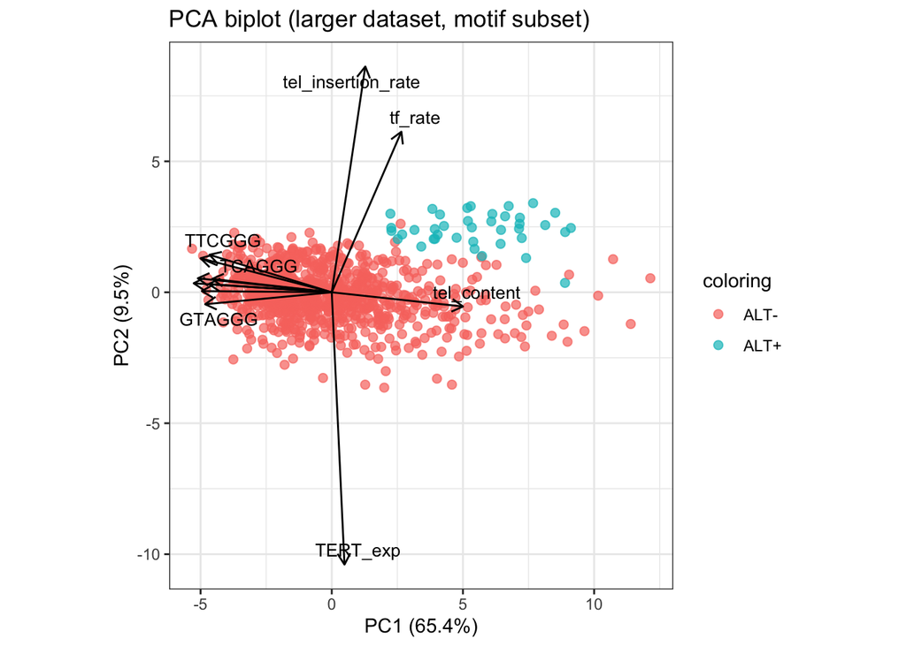

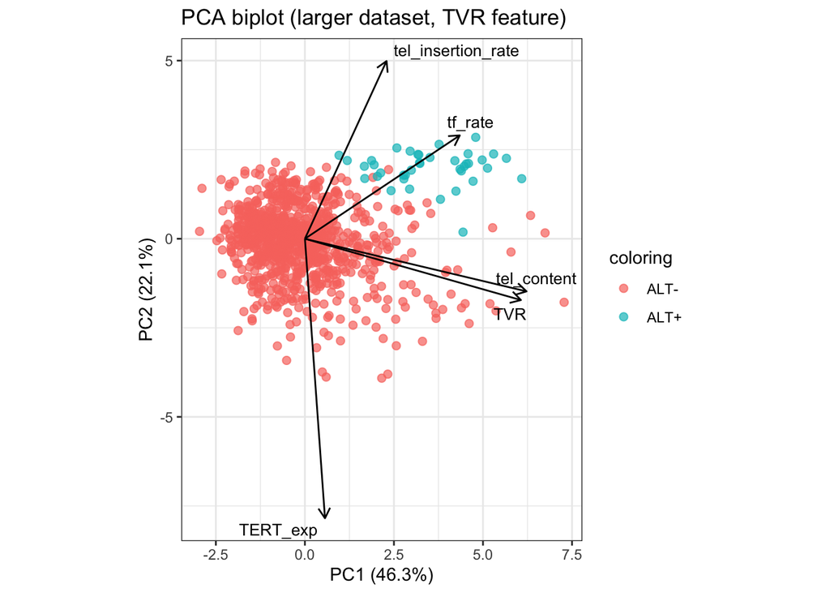

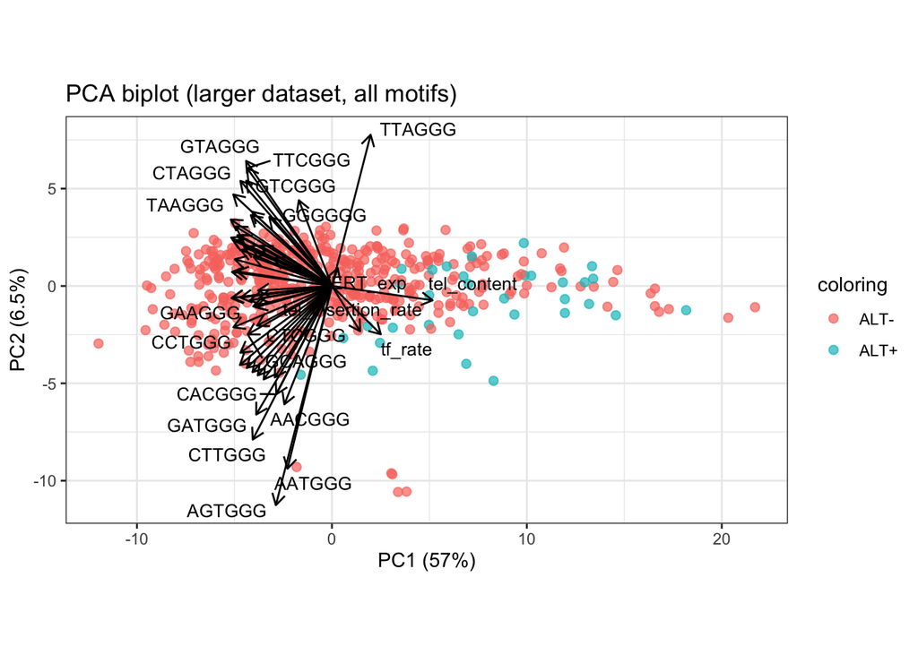